# Timeseries data

## Time series data

Objectives:

- To identify trend, seasonal, cyclic and irregular patterns in a time series
- To perform simple smoothing and forecasting on time series data
- Understand multiplicative and additive decompositions
- Explore data for visualising changes over time

**Warning** Maths ahead!

## Time series data

Numerical data obtained at regular time intervals The time intervals can be annually, quarterly, daily, hourly, etc.

## Plotting time series data

- Scatterplot of values (vertical axis) against time (horizontal axis)
- Join successive values with lines

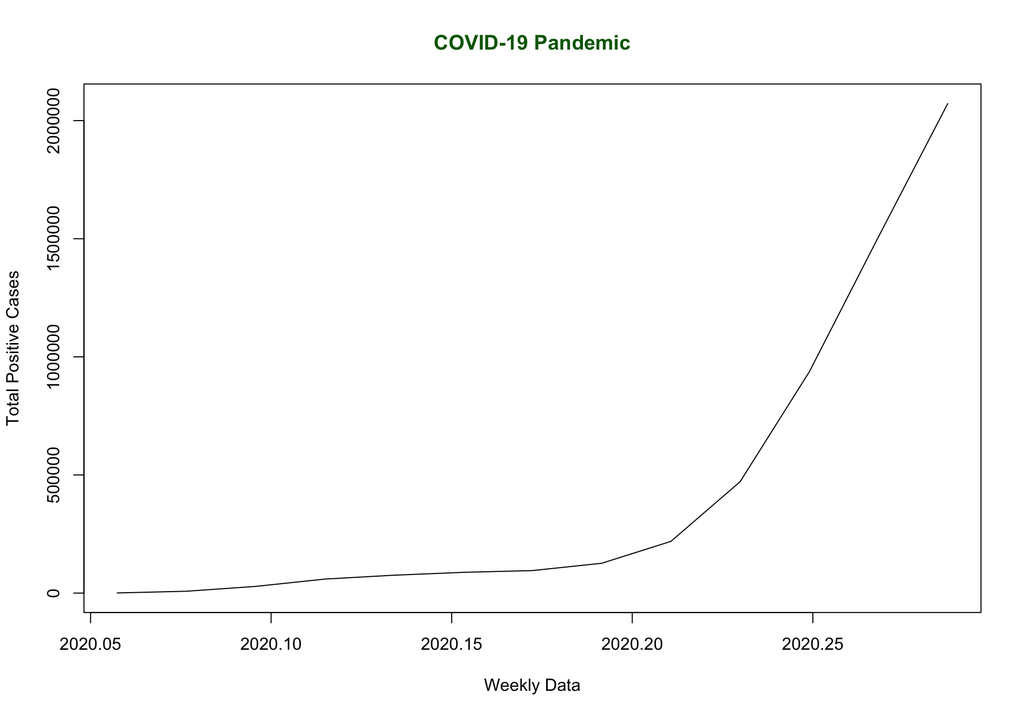

## Multivariate Time Series

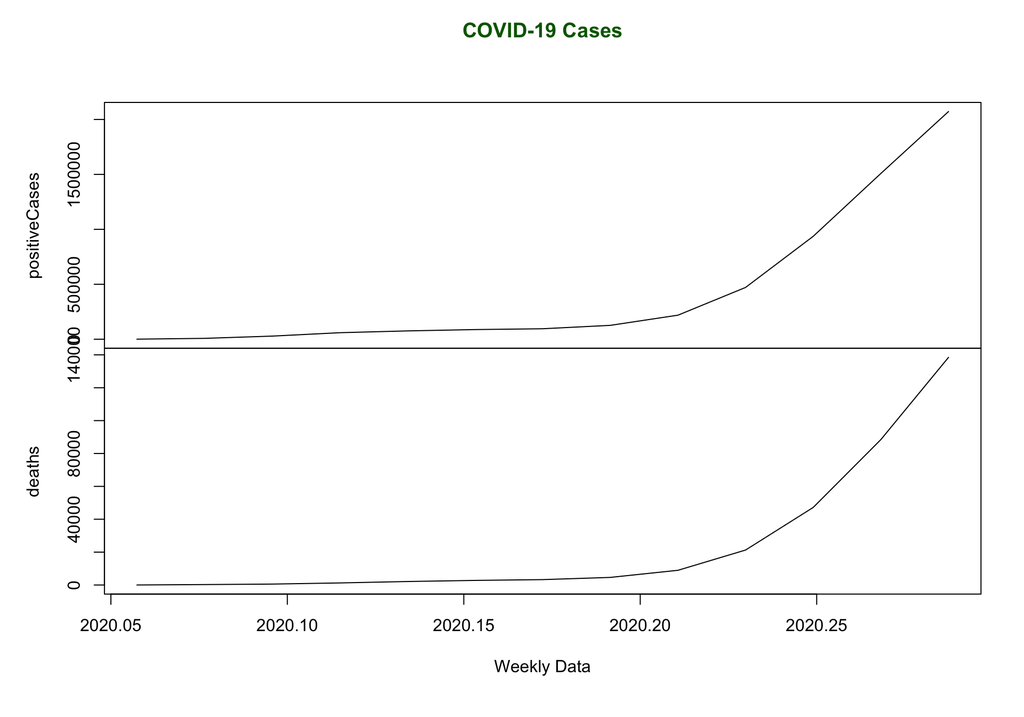

## Four Components

There are four component to a time series:

1.The **trend** which is overall persistent, *long-term movement*;

2. A **seasonal** component seen as *regular* periodic fluctuations usually within a 12-month period
3. The **cyclic** component which is *repeating swing* or movements over more than one year
4. The **irregular** component seen as *erratic* or residual fluctuations

## Decomposition

Time series data can exhibit a variety of patterns, and it is often helpful to split a time series into several components, each representing an underlying pattern category.

Time series decomposition can be **additive** or **multiplicative**:

- Additive decomposition assumes that the components combine linearly:

  $Y(t) = T(t) + S(t) + R(t)$
- Multiplicative decomposition assumes that the components multiply together:

  $Y(t) = T(t) × S(t) × R(t)$

## Simple moving average

Classical method of time series decomposition

A moving average of order $m$ can be written as

$$\hat T_{t} = \frac{1}{m} \sum_{j=-k}^k y_{t+j}$$

where $m = 2k+1$. That is, the estimate of the trend-cycle at time $t$ is obtained by averaging values of the time series within $k$ periods of $t$.

Observations that are nearby in time are also likely to be close in value. Therefore, the average eliminates some of the randomness in the data, leaving a smooth trend-cycle component.

## How to extract the trend, seasonality and error?

The `decompose()` and `forecast::stl()` splits the time series into seasonality, trend and error components.

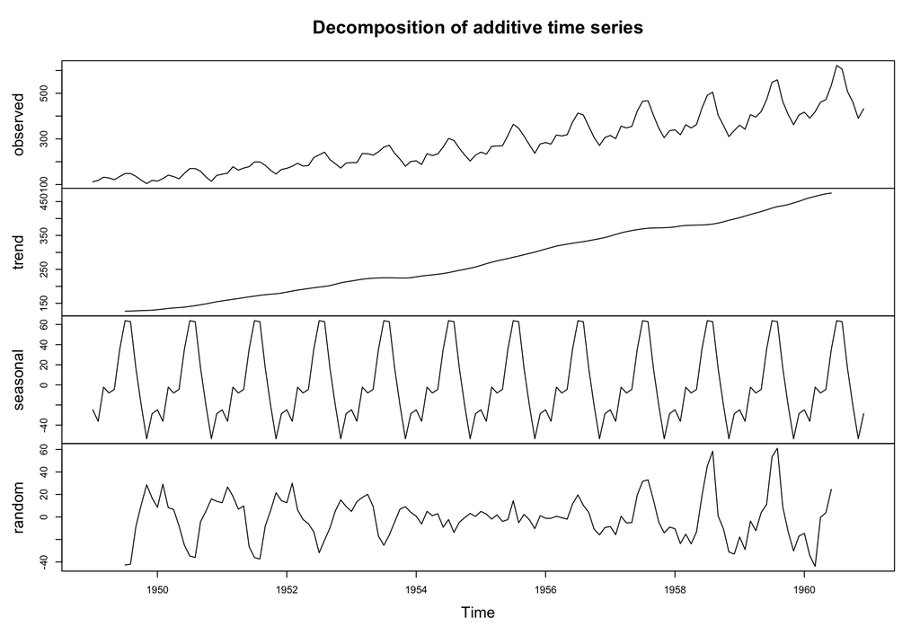

```r
data("AirPassengers")

# Perform additive decomposition,
# for multiplicative change `type`
decomposed_data <- decompose(AirPassengers, type = "additive")

# Plot the decomposition
plot(decomposed_data)
```

## STL decomposition

Seasonal and trend decomposition using LOESS.

LOESS is a method that smooths the data to find non-linear trends and irregular seasonality.

The `s.window = "periodic"` argument specifies a periodic seasonal window.

`stl()` is more flexible than `decompose()` and can handle complex seasonal patterns.

The STL method was developed by R. B. Cleveland, Cleveland, McRae, & Terpenning (1990).

## STL decomposition

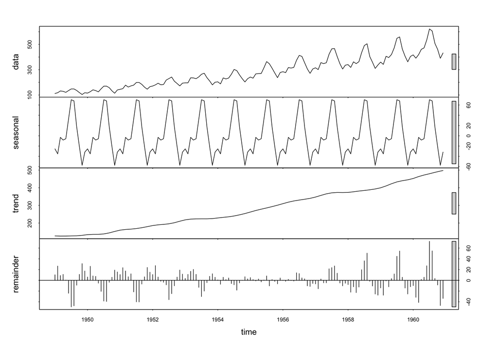

```r
# Perform STL decomposition
stl_decomposed_data <- stl(AirPassengers, s.window = "periodic")

# Plot the decomposition
plot(stl_decomposed_data)
```

## Homoscedasticity

- Many time series models operate under the crucial assumption of homoscedasticity–that the variance of the data remains constant over time.
- However, real world data often violates this assumption, sometimes this is not an error but the thing you want to model (that is hard!)
- Test by fitting a model and examining the squared residuals
- Sometimes transformations help, sometimes they are not appropriate

## Stationary

- Important concept for time series forecasting.
- A stationary time series has statistical properties – mean, variance, and covariance – that do not change over time.
- We want this
- A series that fluctuates around a constant mean with consistent variability means the relationship between observations depends only on how far apart they are in time, not on when you look at them

## Is my time-series stationary or not?

- **Visual assessment** A stationary series would fluctuate around a horizontal line (like random noise), while a non stationary series would show a clear upward or downward trend.
- **Statistical tests** is the Augmented Dickey-Fuller (ADF) test, however the KPSS (Kwiatkowski-Phillips-Schmidt-Shin) test is also widely used, which is available in the feasts package

## Forecasting

Exponential smoothing and ARIMA models are the two most widely used approaches to time series forecasting, and provide complementary approaches to the problem.

While exponential smoothing models are based on a description of the trend and seasonality in the data, ARIMA models aim to describe the autocorrelations in the data.

## Exponential Smoothing

- Forecasts produced using exponential smoothing methods are weighted averages of past observations, with the weights decaying exponentially as the observations get older.
- In other words, the more recent the observation the higher the associated weight.
- This framework generates reliable forecasts quickly and for a wide range of time series, which is a great advantage and of major importance to applications in industry.

## Simple Exponential Smoothing

Suitable for forecasting data with no clear trend or seasonal pattern.

$\hat y_{T+1|T} = \alpha y_{T} + \alpha(1-\alpha) y_{T-1} + \alpha(1-\alpha)^2 y_{T-2}+ \cdots$

where $0 \le \alpha \le1$.

- The one-step-ahead forecast for time $T+1$ is a weighted average of all of the observations in the series $y_{1},..., y_{T}$.
- The rate at which the weights decrease is controlled by the parameter $\alpha$.

## ARIMA model

- AutoRegressive Integrated Moving Average
- leverage the autocorrelation structure of your data – the relationship between observations at different time lags.
- Model that learns how today’s value relates to yesterday’s, last week’s and last month’s values, then uses those relations to predict tomorrow.

## ARIMA Components

- AutoRegressive (AR)
  - captures the relationship between a current observation and a linear combination of its immediate predecessors
- Integrated (I)
  - handles the process of differencing the data to make the series stationary
- Moving Average (MA)
  - models the relationship between the current observation and previous forecast errors (or residuals)

Also see: `ARIMA()` function is used to fit an ARIMA model in the `fable` framework

https://gkagyen.quarto.pub/tstidyway/

## ARIMA model

In base R, uses `stats` package and other usually already loaded libraries

```r
fit <- auto.arima(mts) # here mts is a ts() object made from stats package

forecasted_values <- forecast(fit, 5)

print(forecasted_values)
```

```
         Point Forecast   Lo 80   Hi 80   Lo 95   Hi 95
2020.307        2547989 2491957 2604020 2462296 2633682
2020.326        2915129 2721276 3108982 2618657 3211602
2020.345        3202354 2783401 3621306 2561621 3843086
2020.364        3462691 2748533 4176849 2370481 4554902
2020.383        3745055 2692886 4797223 2135901 5354208
```

## Plot forecast

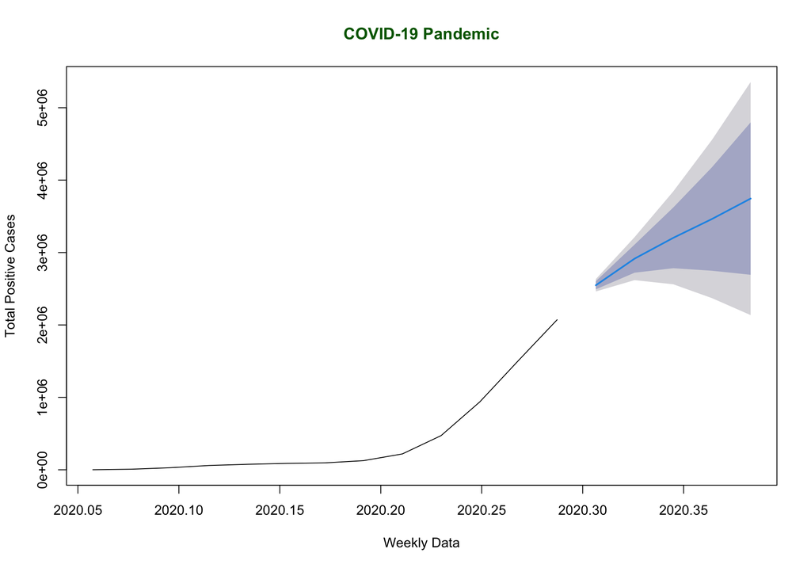

## Difference

- Sometimes you are given time series data but you (researchers) are really interested in changes over time.
- This can require a little wrangling

## Scenario

Abundance of birds encountered during the survey time along 1km of shoreline. (Dogs, humans and marine mammals are also recorded.)

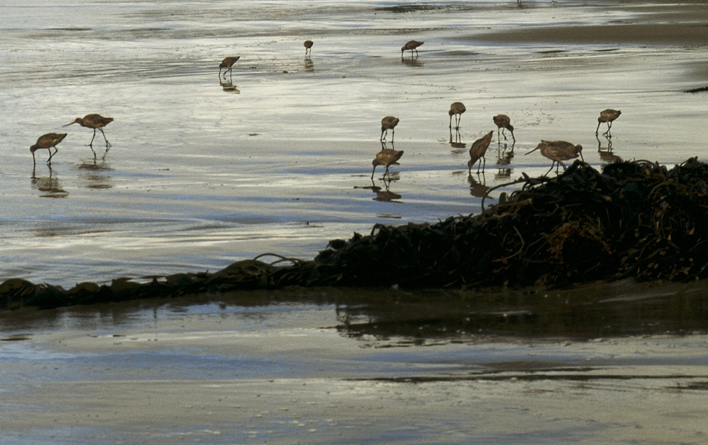

Data: Dugan, J, K. Emery. 2026. SBC LTER: Beach: Time series of abundance of birds and stranded kelp on selected beaches, ongoing since 2008 ver 13. Environmental Data Initiative. https://doi.org/10.6073/pasta/bb941a62202759f037eaf69ad3ffcc0a. Accessed 2026-09-15.

## Load data

```
Rows: 148,096
Columns: 15
$ YEAR          <int> 2008, 2008, 2008, 2008, 2008, 2008, 2008, 2008, 2008, 20…
$ MONTH         <int> 11, 11, 11, 11, 11, 11, 11, 11, 11, 11, 11, 11, 11, 11, …
$ DATE          <chr> "10/29/2008", "10/30/2008", "10/31/2008", "11/03/2008", …
$ SITE          <chr> "SCLB", "IVWB", "EUCB", "ABB", "SCLB", "SCLB", "SCLB", "…
$ COMMON_NAME   <chr> "OSPREY", "OSPREY", "OSPREY", "OSPREY", "BLACK BRANT", "…
$ TOTAL         <int> 0, 0, 0, 0, 0, 0, 0, 0, 0, 0, 0, 0, 0, 0, 0, 0, 0, 0, 0,…
$ TAXON_GENUS   <chr> "Pandion", "Pandion", "Pandion", "Pandion", "Branta", "B…
$ TAXON_SPECIES <chr> "haliaetus", "haliaetus", "haliaetus", "haliaetus", "nig…
$ TAXON_GROUP   <chr> "hawk", "hawk", "hawk", "hawk", "goose", "goose", "shore…
$ SURVEY        <chr> "Shorebirds", "Shorebirds", "Shorebirds", "Shorebirds", …
$ TAXON_KINGDOM <chr> "Animalia", "Animalia", "Animalia", "Animalia", "Animali…
$ TAXON_PHYLUM  <chr> "Chordata", "Chordata", "Chordata", "Chordata", "Chordat…
$ TAXON_CLASS   <chr> "Aves", "Aves", "Aves", "Aves", "Aves", "Aves", "Aves", …
$ TAXON_ORDER   <chr> "Accipitriformes", "Accipitriformes", "Accipitriformes",…
$ TAXON_FAMILY  <chr> "Pandionidae", "Pandionidae", "Pandionidae", "Pandionida…
```

## Explore the data

- Looks like we have year, month and date columns. But `MONTH` isn’t the same month as in the `DATE` column (deep sigh)
- This is long format data. Each row is a survey date and a bird species, total is that count of that species on that day
- Let’s explore the question how does abundance and richness of shorebirds changed over time.

## Wrangle

```r
shorebird_summary <- shorebirds |>
  # only need the birds that were actually observed
  # filter for only shorebirds
  filter(TAXON_GROUP == "shorebird", TOTAL > 0) |>
  # count for each survey
  group_by(YEAR, MONTH, SITE) |>
  summarise(abundance = sum(TOTAL),
         richness = n_distinct(COMMON_NAME),
         .groups = "drop")

# I am bad at capitalization so low case column names for me
colnames(shorebird_summary) <- tolower(colnames(shorebird_summary))
```

## EDA: Abundance

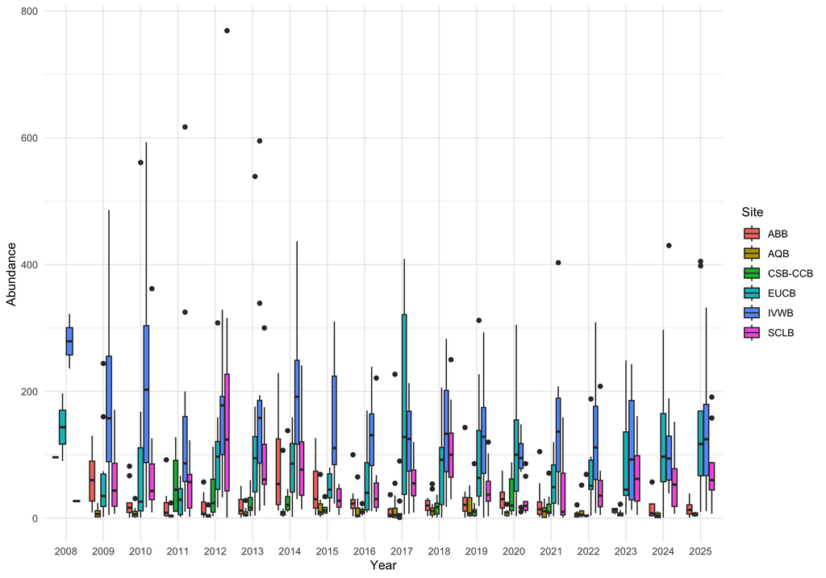

## EDA: Richness

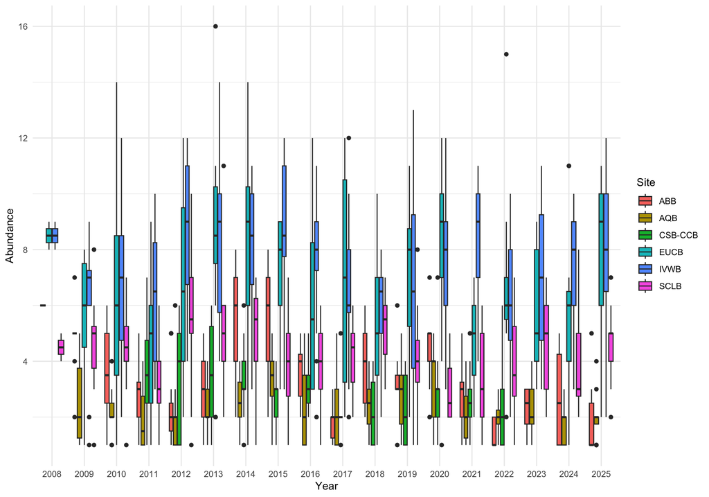

## To include or not to include?

If we drop 2008 (since it is a part year) then have data Jan 2009 - Dec 2025

```r
shorebird_summary2 <- shorebirds |>
  # only need the birds that were actually observed
  # filter for only shorebirds
  filter(TAXON_GROUP == "shorebird", TOTAL > 0, YEAR > 2008) |>
  # count for each survey
  group_by(YEAR, MONTH, SITE) |>
  summarise(abundance = sum(TOTAL),
         richness = n_distinct(COMMON_NAME),
         .groups = "drop")

# I am bad at capitalization so low case column names for me
colnames(shorebird_summary2) <- tolower(colnames(shorebird_summary2))
```

We lose only 7 observations (2 months sampled: 3 sites 1 month and 4 sites the other month)

## How many surveys were acutally done?

```
# A tibble: 6 × 4
  SITE    total_surveys months_sampled years_sampled
  <chr>           <int>          <int>         <int>
1 ABB               202             12            17
2 AQB               202             12            17
3 CSB-CCB           129             12            12
4 EUCB              203             12            17
5 IVWB              203             12            17
6 SCLB              202             12            17
```

Hmmmm?

Looks like site `CSB-CCB` was added later in the time series (2011)

## Make a date

```r
shorebird_summary2 <- shorebird_summary2 |>
  mutate(date = make_date(year = year, month = month))

glimpse(shorebird_summary2)
```

```
Rows: 1,011
Columns: 6
$ year      <int> 2009, 2009, 2009, 2009, 2009, 2009, 2009, 2009, 2009, 2009, …
$ month     <int> 1, 1, 1, 1, 1, 2, 2, 2, 2, 2, 3, 3, 3, 3, 3, 4, 4, 4, 4, 4, …
$ site      <chr> "ABB", "AQB", "EUCB", "IVWB", "SCLB", "ABB", "AQB", "EUCB", …
$ abundance <int> 21, 24, 74, 167, 20, 60, 2, 24, 281, 80, 70, 7, 18, 222, 171…
$ richness  <int> 4, 5, 8, 8, 5, 5, 2, 6, 7, 5, 5, 2, 5, 7, 6, 5, 4, 4, 7, 5, …
$ date      <date> 2009-01-01, 2009-01-01, 2009-01-01, 2009-01-01, 2009-01-01,…
```

## EDA: Abundance time series

Simple line plot

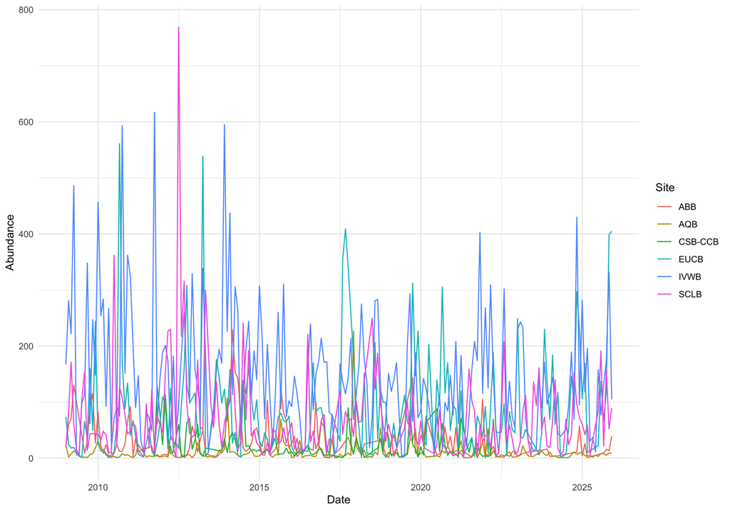

## EDA: Abundance time series

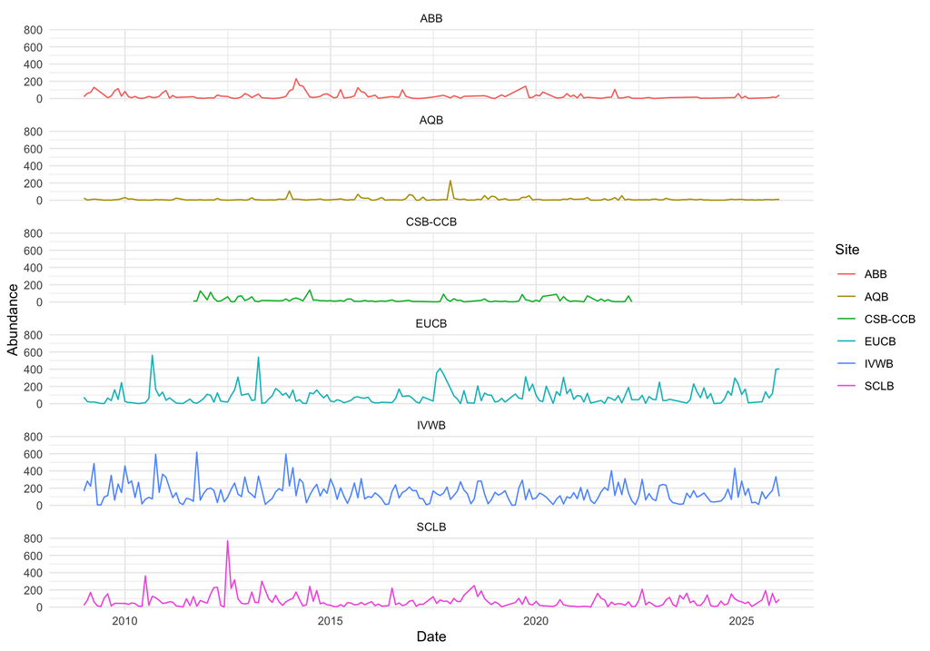

Better… but not great…

## Time series analysis

- From here you could improve the plot: scale y axis, titles, etc.
- Time series analyses:
  - decompose
  - examine seasonal signal vs trend
- But why was the data collected? what do they want to ask?

## Calculate change

How does shorebird abundance and richness change at each site, month to month, across years?

```r
shorebird_change <- shorebird_summary2 |>
  group_by(year, site) |>
  tidyr::gather(key, value, -year, -month, -site) |>
  group_by(year, site, key) |>
  arrange(month, .by_group = TRUE) |>
  mutate(value_diff = value - lag(value),
         date = make_date(year = year, month = month))
```

Warning because not every site was sampled for the whole time series, we already figured that out

## Plot change in abundance over time

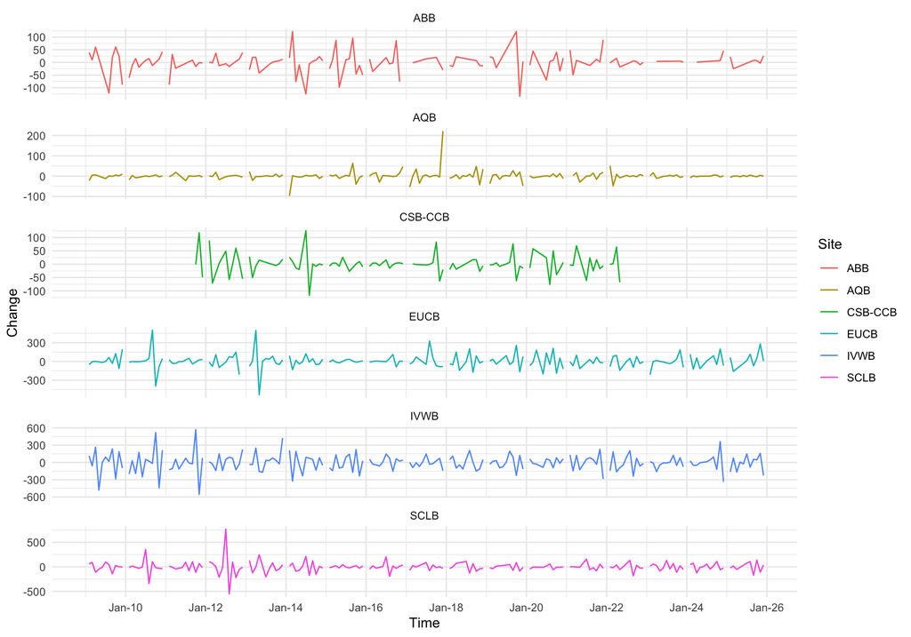

## Plot change in richness over time

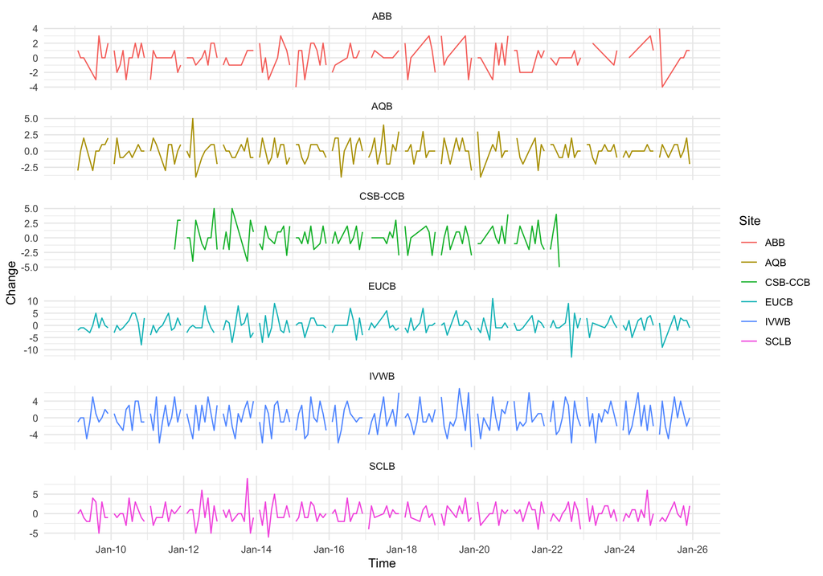

## Annual change

```r
shorebird_change_yr <- shorebird_summary2 |>
  group_by(site, year) |>
  dplyr::summarise(
    med_abundance = median(abundance),
    med_richness = median(richness),
    .groups = "drop"
  ) |>
  pivot_longer(
    cols = c(med_abundance, med_richness),
    names_to = "key",
    values_to = "value"
  ) |>
  arrange(site, key, year) |>
  group_by(site, key) |>
  mutate(value_diff = value - lag(value)) |>
  ungroup()
```

## Plot

Annual median abundance over time

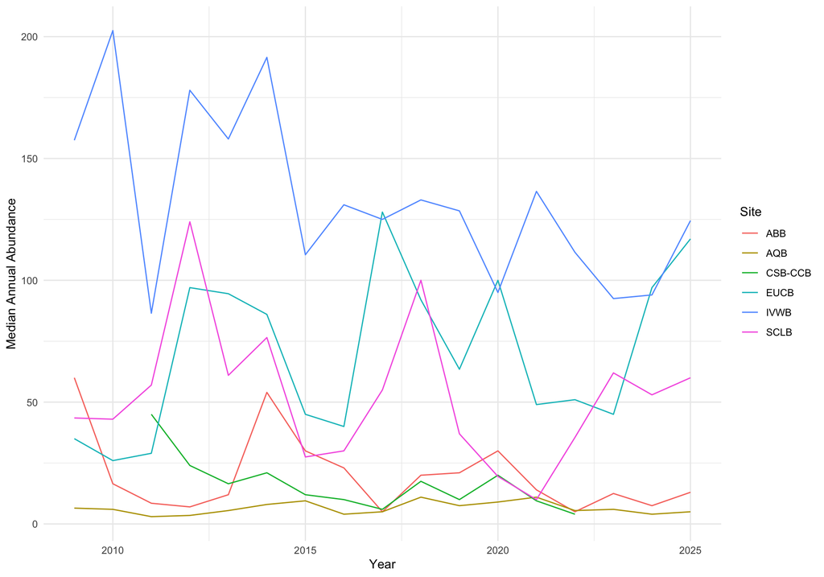

**Change** in annual median abundance over time

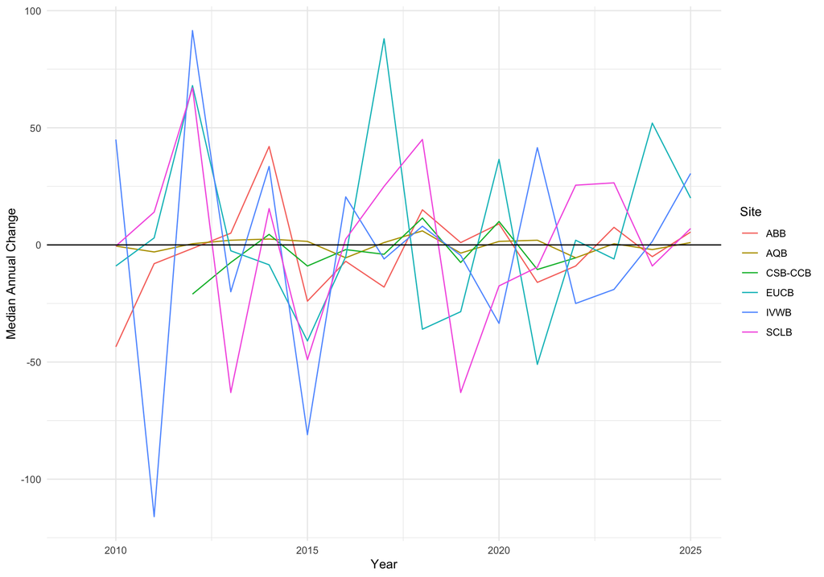

## Shorebird Summary

- How does shorebird abundance and richness change at each site, across years?
  - data from Jan 2009 - Dec 2025 only (summary table)
  - calculated median annual abundance/richness
  - plot median annual abundance/richness over time
  - plot difference in median annual abundance/richness
- Next steps:
  - Add variability to plots?
  - Seasons? migrating, nesting, fledging?
  - Unit of time of interest?
  - Decomposition? seasonal patterns vs trend
  - Forecasting?

## Dealing with gaps

- Real-world data is messy. Sensors fails, public holidays happen, data does not get entered.
- This leads to gaps in our time series – missing entries in the index where we expect a measurement.
- Many time series models and visualisations assume regular spaced data.
- Gaps can lead to errors, misleading plots and inaccurate forecasts.

## Summary

- This topic has been an overview of time as variable, it is not comprehensive

You should now be able to:

- To identify trend, seasonal, cyclic and irregular patterns in a time series
- To perform simple smoothing and forecasting on time series data
- Understand multiplicative and additive decompositions
- Explore data for visualising changes over time

## Other plot styles that might be useful

- Cleveland dot plots

  https://r-graph-gallery.com/303-lollipop-plot-with-2-values.html
- Interactive plots

  https://r-graph-gallery.com/interactive-charts.html

## Things not covered but you might want to know about

## Different formats of writing dates

- `lubridate` has wrappers you can use to adjust these as long as you know what the original format is

| Month Names | Numbers only |
| --- | --- |
| August 25, 2026 | 08/25/26 |
| 25 August 2026 | 25/08/26 |
| 2026 August 25 | 26/08/25 |

## Julian date

- Julian day is a continuous count of days from the beginning of the Julian period.
- sometimes in software for easily calculating elapsed days between two events (e.g., food production date and expiration date).

## Timezones and daylight saving

- `lubridate` can be used to convert timezones and 24 vs 12 hour clock
- see https://codepointtech.com/mastering-r-time-zones-with-lubridate-your-ultimate-guide/ for examples
- be explicit in meta data or use UTC as a default

## BACI design

Special case, experimental design in ecology and environmental impacts

Before-After Control-Impact (BACI) design compares changes over time at an impacted site to changes at a control site to evaluate environmental disturbances.

It uses data from both before and after an impact at two sites to account for natural variations and isolate the effect of the disturbance.

Hard to do in real life, how do you know when a disturbance will occur

## References

https://codepointtech.com/mastering-tidyverse-for-time-series-analysis-in-r/

https://www.geeksforgeeks.org/r-language/time-series-analysis-in-r/

https://r-statistics.co/Time-Series-Analysis-With-R.html

https://r-graph-gallery.com/time-series.html

https://gkagyen.quarto.pub/tstidyway/

https://nicholasrjenkins.science/post/tidy_time_series/tts_r/